# hw7

Ben Camber

2/26/2020

### Creating fake data sets to explore hypotheses

1. Go back to your “thinking on paper” exercise, and decide on a pattern that you might expect in your experiment if a specific hypothesis were true. *I hypothesize that Leptopilina boulardi strains Lb17 and G486 will have different mean encapsulation rates and that that distribution of encapsulation rates will follow a normal distribution, and G486 will have more variance than Lb17.*
2. To start simply, assume that the data in each of your treatment groups follow a normal distribution. Specify the sample sizes, means, and variances for each group that would be reasonable if your hypothesis were true.

```r
lb17<-rnorm(n=1000,mean=90,sd=5)
g486<-rnorm(n=1000,mean=80,sd=7.5)
```

3. Using the methods we have covered in class, write code to create a random data set that has these attributes. Organize these data into a data frame or tibble with the appropriate structure.

```r
wasps<-data.frame(lb17,g486,stringsAsFactors = FALSE)
library(tidyr)
wasps2<-gather(wasps,strain,encap_rate)
head(wasps2)
```

```
##   strain encap_rate
## 1   lb17   86.85865
## 2   lb17   92.84872
## 3   lb17  102.03382
## 4   lb17   87.43867
## 5   lb17   86.49573
## 6   lb17   92.99084
```

4. Now write code to analyze the data (probably as an ANOVA or regression analysis, but possibly as a logistic regression or contingency table analysis. Write code to generate a useful graph of the data.

```r
encap_model<-aov(encap_rate~strain,data=wasps2)
summary(encap_model)
```

```
##               Df Sum Sq Mean Sq F value Pr(>F)
## strain         1  52439   52439    1229 <2e-16 ***
## Residuals   1998  85256      43
## ---
## Signif. codes:  0 '***' 0.001 '**' 0.01 '*' 0.05 '.' 0.1 ' ' 1
```

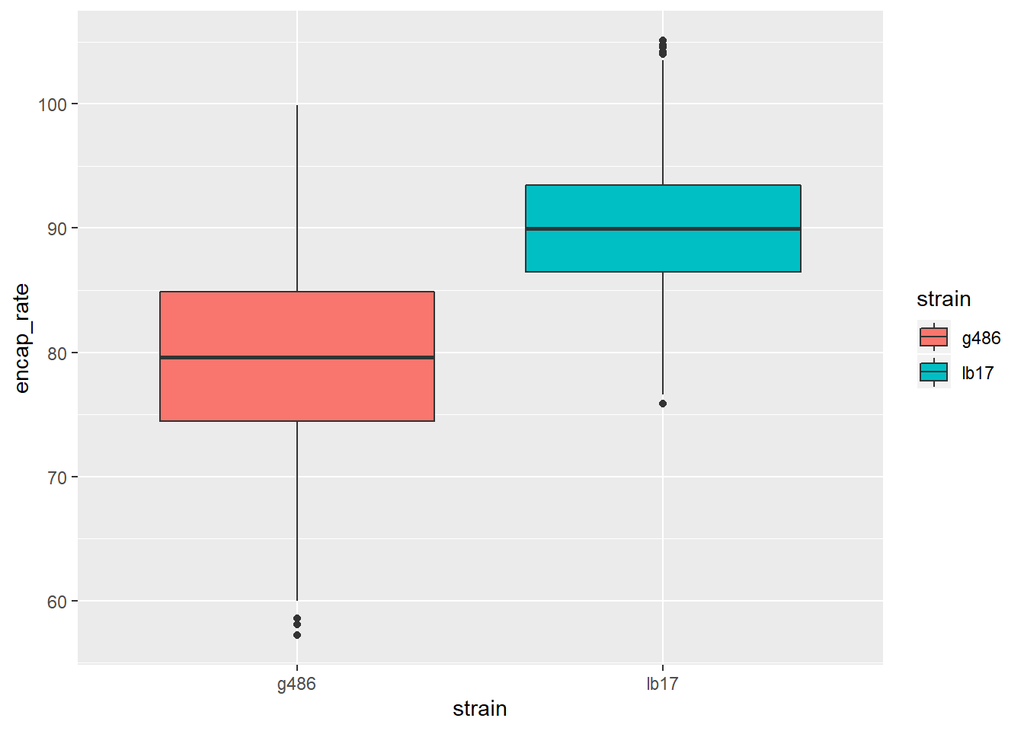

```r
library(ggplot2)
encap_plot<-ggplot(data=wasps2,aes(x=strain,y=encap_rate,fill=strain)) +
  geom_boxplot()
encap_plot
```

```r
lb17<-rnorm(n=1000,mean=90,sd=5)
g486<-rnorm(n=1000,mean=89.1,sd=7.5)
wasps<-data.frame(lb17,g486,stringsAsFactors = FALSE)
wasps2<-gather(wasps,strain,encap_rate)
encap_model<-aov(encap_rate~strain,data=wasps2)
summary(encap_model)
```

```
##               Df Sum Sq Mean Sq F value  Pr(>F)
## strain         1    439   439.2   10.31 0.00134 **
## Residuals   1998  85099    42.6
## ---
## Signif. codes:  0 '***' 0.001 '**' 0.01 '*' 0.05 '.' 0.1 ' ' 1
```

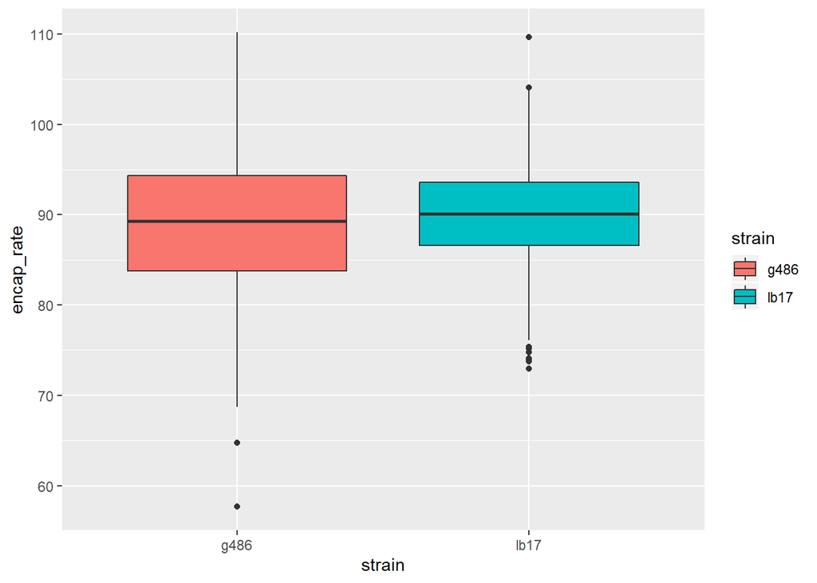

```r
encap_plot<-ggplot(data=wasps2,aes(x=strain,y=encap_rate,fill=strain)) +
  geom_boxplot()
encap_plot
```

7.Alternatively, for the effect sizes you originally hypothesized, what is the minimum sample size you would need in order to detect a statistically significant effect? Again, run the model a few times with the same parameter set to get a feeling for the effect of random variation in the data. *With only 5 observations of the encapsulation rate of each strain, there was a signficant difference in the strains 8/10 runs of the model.*

```r
lb17<-rnorm(n=5,mean=90,sd=5)
g486<-rnorm(n=5,mean=80,sd=7.5)
wasps<-data.frame(lb17,g486,stringsAsFactors = FALSE)
wasps2<-gather(wasps,strain,encap_rate)
encap_model<-aov(encap_rate~strain,data=wasps2)
summary(encap_model)
```

```
##             Df Sum Sq Mean Sq F value Pr(>F)
## strain       1  118.4  118.38   3.439  0.101
## Residuals    8  275.4   34.42
```

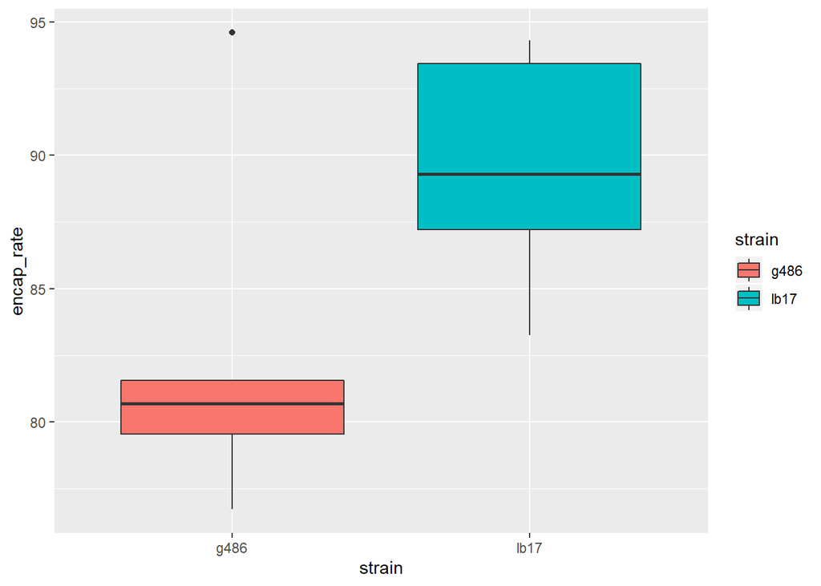

```r
encap_plot<-ggplot(data=wasps2,aes(x=strain,y=encap_rate,fill=strain)) +
  geom_boxplot()
encap_plot
```